# GLM_MLM_FINAL

Erik Ketterer, Sagan Kakkar, Yamin Zhang, Yining Guan

2023-05-02

## Load libraries

```r
remove(list = ls())
library(lme4)
library(gridExtra)
library(tidyverse)
```

```r
library(ggplot2)
library(kableExtra)
library(dplyr)
library(haven)
```

# Part1 GML Regression Report

## Load data

```r
fertil2 <- read.csv("data.csv")
```

## Parameter fine-tuning

This data was obtained by James Heakins, a former MSU undergraduate, for a project. The original data comes from Botswana’s 1988 Demographic and Health Survey.

The response variable/parameter of interest is ‘children’, the number of living children. We are trying to predict the number of living children using the explanatory variables ‘age’, ‘urban’, ‘educ’, and ‘usemeth’, and whether this is an effective model of prediction.

We want to estimate ‘children’ by: ‘age’, which is the current age in years of mother, ‘urban’, which is 1 if mother lives in urban area, 0 if not ‘educ’, which is the number of years of education the mother has ‘usemeth’, which is 1 if the mother has ever used birth control and 0 otherwise. ‘agefm’, which is age of mother at first marriage.

The variables ‘age’, ‘education’ and ‘agefm’ are numerically meaningful, while ‘urban’ and ‘usemeth’ are binary.

The variable ‘usemeth’, and ‘agefm’ has 2332 NA values in total, which we will omit from the select dataset.

The data are available at website: [Data Resource](https://justinmshea.github.io/wooldridge/reference/fertil2.html#source)

```r
selectData <- fertil2 %>%
  select(children, age, urban, educ, usemeth, agefm) %>%
  na.omit()
head(selectData)
```

```
##   children age urban educ usemeth agefm
## 2        3  32     1   13       1    24
## 3        1  30     1    5       0    24
## 4        2  42     1    4       0    15
## 5        2  43     1   11       1    20
## 6        1  36     1    7       1    24
## 7        4  37     1   16       1    26
```

```r
str(selectData)
```

```
## 'data.frame':    2029 obs. of  6 variables:
##  $ children: int  3 1 2 2 1 4 1 0 3 3 ...
##  $ age     : int  32 30 42 43 36 37 34 49 42 29 ...
##  $ urban   : int  1 1 1 1 1 1 1 1 1 1 ...
##  $ educ    : int  13 5 4 11 7 16 5 4 15 7 ...
##  $ usemeth : int  1 0 0 1 1 1 1 0 1 1 ...
##  $ agefm   : int  24 24 15 20 24 26 18 22 24 24 ...
##  - attr(*, "na.action")= 'omit' Named int [1:2332] 1 8 16 17 18 25 28 29 30 32 ...
##   ..- attr(*, "names")= chr [1:2332] "1" "8" "16" "17" ...
```

## Research question

### Question 1

Is the model using parameters ‘agefm’, ‘edu’, and ‘usemeth’ to predict the response variable ‘children’ efficient?  
### Question 2  
Is the model using parameters ‘age’, ‘edu’, and ‘urban’ to predict the response variable ‘children’ efficient?  
### Question 3 Which model is better?

## EDA

### Univariate Analysis

- ‘children’

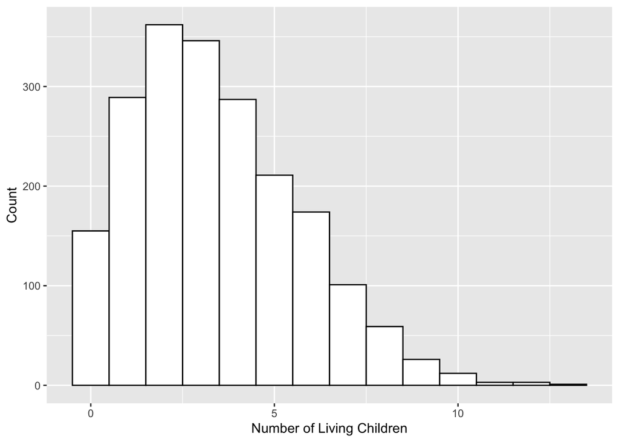

```r
ggplot(data = selectData, mapping = aes(x = children)) +
  geom_histogram(binwidth = 1, fill = "white", color = "black") +
  labs(x = "Number of Living Children",
       y = "Count")
```

From the graph, we can see the number of children follows right skewed normal distribution with mean value at around 3 and 4. This also indicates that our response variable appears to follow poisson distribution.

- “age”

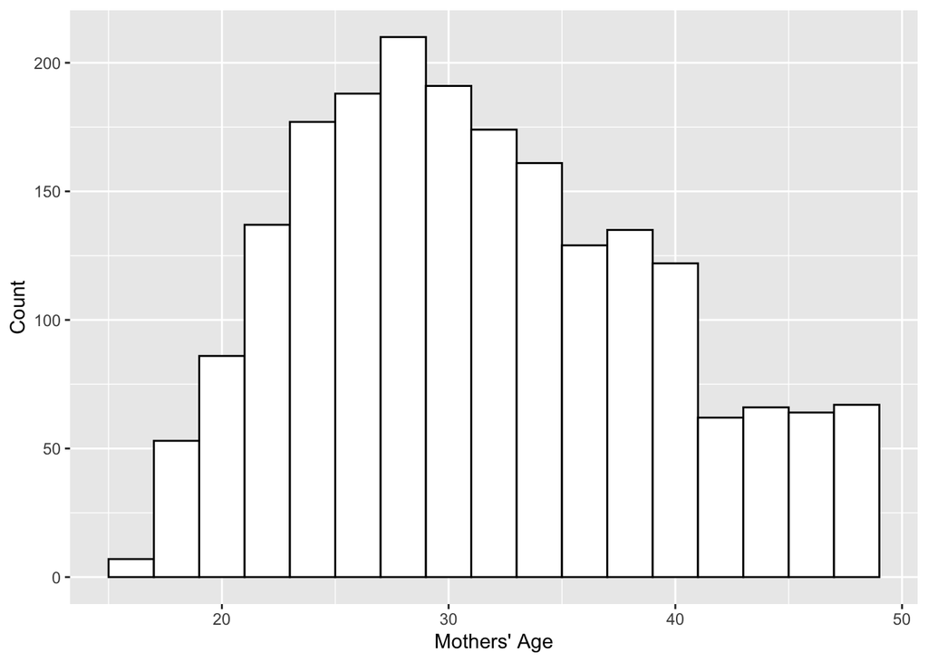

```r
ggplot(data = selectData, mapping = aes(x = age)) +
  geom_histogram(binwidth = 2, fill = "white", color = "black") +
  labs(x = "Mothers' Age",
       y = "Count")
```

From graph above, the age of mothers seems like to follow normal distribution even if there is a tail on the right side.

- “urban”

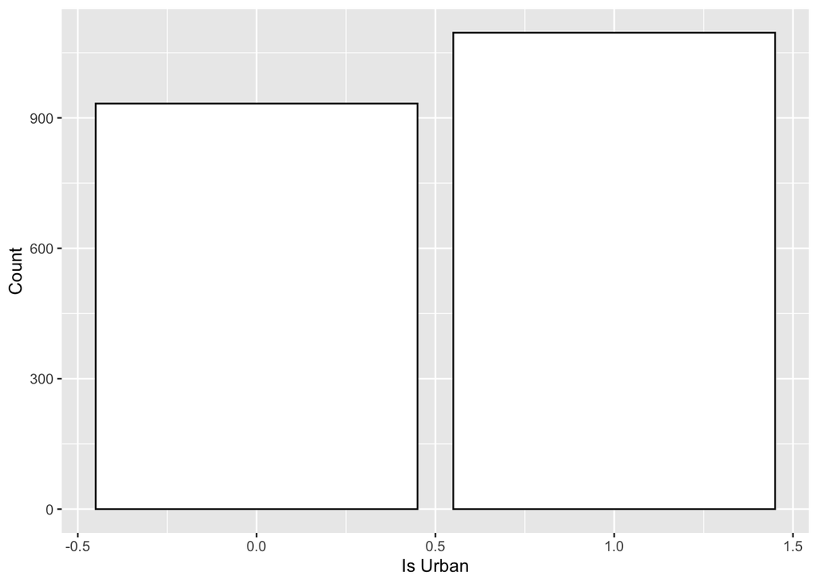

```r
ggplot(data = selectData, mapping = aes(x = urban)) +
  geom_bar(fill = "white", color = "black") +
  labs(x = "Is Urban",
       y = "Count")
```

```r
#Find the counts of each urban type
table(selectData$urban)
```

```
##
##    0    1
##  933 1096
```

```r
#Find the proportion for urban
prop.table(table(selectData$urban))
```

```
##
##         0         1
## 0.4598324 0.5401676
```

From the plot and the table above, the number of mothers living in urban area is pretty close to the number of mothers who do not live in urban area. There are 1096 mothers (p = .54) in urban areas and 933 mothers (p = .46) living in other areas.

- “educ’

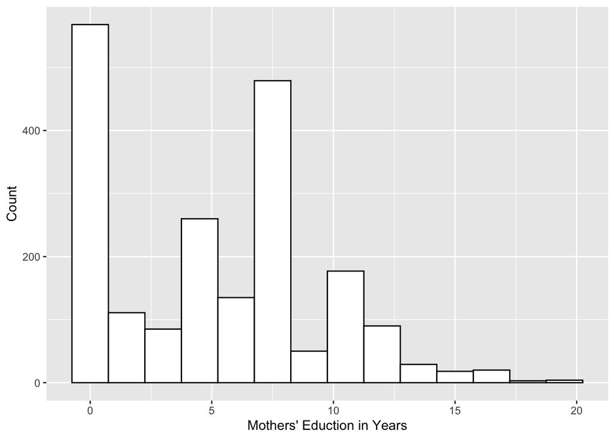

```r
ggplot(data = selectData, mapping = aes(x = educ)) +
  geom_histogram(binwidth = 1.5, fill = "white", color = "black") +
  labs(x = "Mothers' Eduction in Years",
       y = "Count")
```

From the graph, we can see that there are two values (educ=0 and educ=7) in education appearing to be significant large, which means the most of women in Botswana have no education or just elementary education.

- “usemeth”

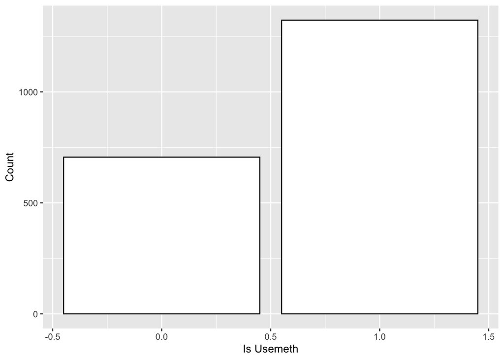

```r
ggplot(data = selectData, mapping = aes(x = usemeth)) +
  geom_bar(fill = "white", color = "black") +
  labs(x = "Is Usemeth",
       y = "Count")
```

```r
#Find the counts of usemeth
table(selectData$usemeth)
```

```
##
##    0    1
##  706 1323
```

```r
#Find the proportion for each usemeth type
prop.table(table(selectData$usemeth))
```

```
##
##         0         1
## 0.3479547 0.6520453
```

From graph, there seems like a big difference in the number of mother using birth control and the number of mother that does not use birth control. In the table we can see that the number of mothers who use birth control is about twice that of not; 1323 (p = 0.65) compared to 706 who do not (p = .35).

- “agefm’

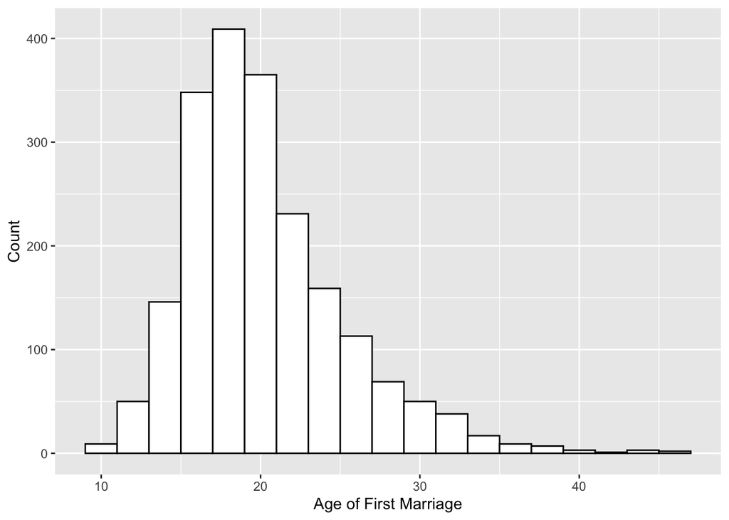

```r
ggplot(data = selectData, mapping = aes(x = agefm)) +
  geom_histogram(binwidth = 2, fill = "white", color = "black") +
  labs(x = "Age of First Marriage",
       y = "Count")
```

From the graph, the age of first marriage approximately follows normal distribution with mean at 20, and it seems to be right skewed.

### Multivariate Analysis

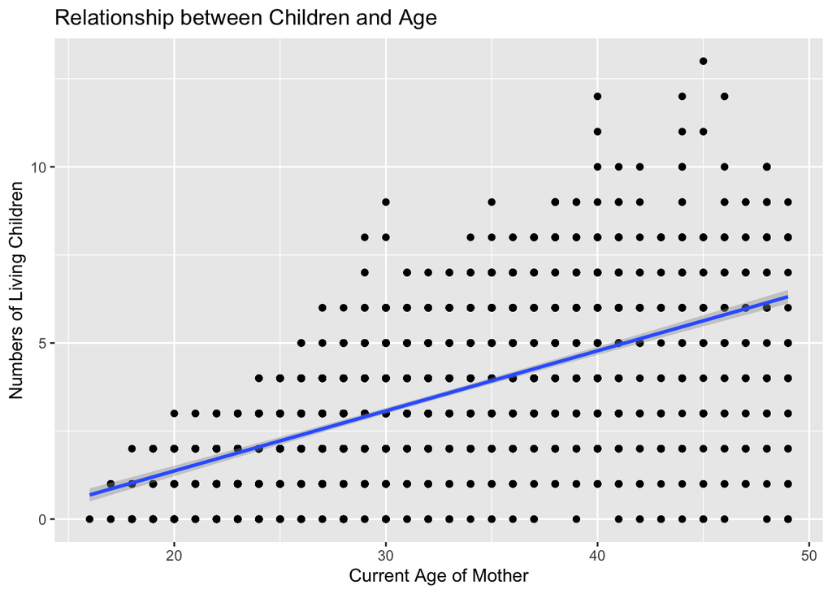

```r
ggplot(data = selectData, aes(x = age, y = children)) + geom_point() + geom_smooth(method = "lm") + labs(x = "Current Age of Mother", y = "Numbers of Living Children", title = "Relationship between Children and Age")
```

According to the graph, from the smooth line, we can see that the relationship between `age` and `children` is positively related, which means the older the current age of mother is, we can assume the more numbers of living children she had.

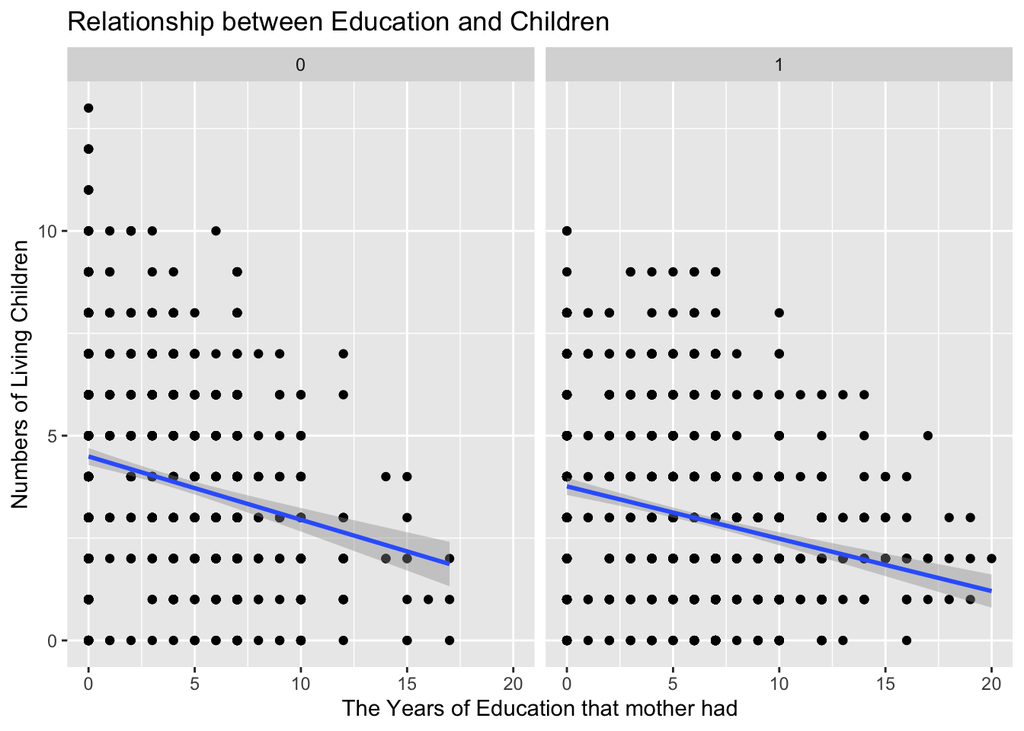

```r
ggplot(data = selectData, aes(x = educ, y = children)) + geom_point() + facet_grid(.~ urban)+ geom_smooth(method = "lm") + labs(x = "The Years of Education that mother had", y = "Numbers of Living Children", title = "Relationship between Education and Children")
```

According to the graph above, we can see that the the smooth line here is negative treding, which means the relationship between `educ` and `children` is negatively related no matter if the mother lived in the urban area or not. In that case, we can say that as the education that the mother has increases, we expect the number of living children that she has to decrease.

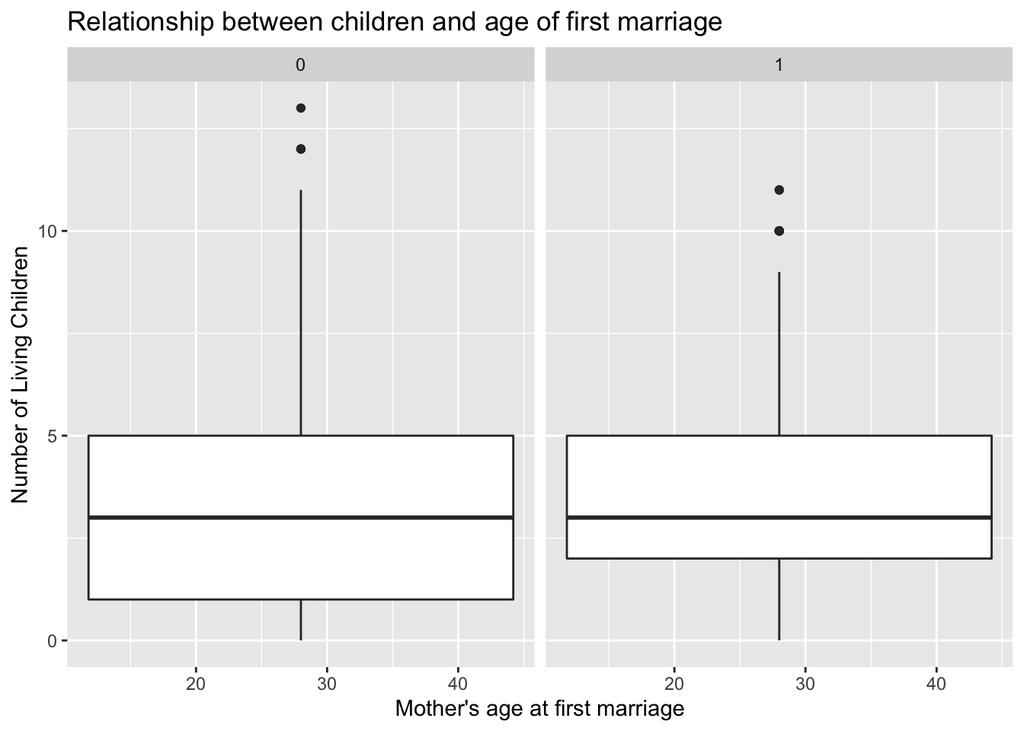

```r
ggplot(data = selectData, aes(x = agefm, y = children)) + geom_boxplot() + facet_grid(. ~ usemeth) + labs(x = "Mother's age at first marriage", y = "Number of Living Children", title = "Relationship between children and age of first marriage")
```

According to the plot above, we can see that the mean numbers of living children that a mother had is roughly same no matter she had ever uses the birth control or not. But the highest number of children that a mother comes from the group that never uses the birth control. What’s more, the range of the numbers of living children is wider in the group that never uses the birth control, which I think we can say the mothers who had used birth control were more in control of their desired number of children.

## Model 1

### Poisson Response

Our response variable is the number of children each mother has. It’s a count value and it can be described by a Poisson Process. From the children data above, it follows right skewed normal distribution, so this also shows it’s a Poisson Response.

### Independence

In our project, each observation is a different mother, so it is reasonable to assume that each observation is independent to each other.

### Mean = Variance

- ‘educ’

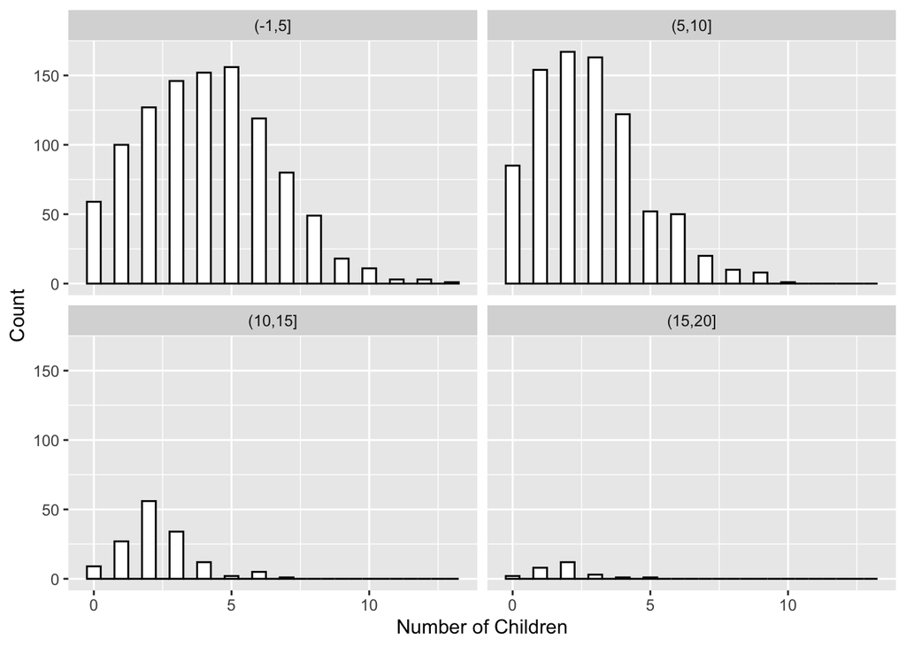

```r
cuts = cut(selectData$educ,
           breaks=c(-1,5,10,15,20))
educGrps <- data.frame(cuts, selectData)
ggplot(data = educGrps, aes(x = children)) +
  geom_histogram(binwidth = .5, color = "black",
                 fill = "white") +
  facet_wrap(cuts) +
  xlab("Number of Children") +
  ylab("Count")
```

```r
# Mean = Variance
table1chp4<- educGrps  %>% group_by(cuts)  %>%
  summarise(mnNum= mean(children),varNum=var(children),n=n())
kable(table1chp4, booktabs=T,
      caption="Compare mean and variance of number of children within each education group.",
      col.names = c("Age Groups", "Mean", "Variance", "n")) %>%
  kable_styling(full_width = F)
```

Compare mean and variance of number of children within each education group.

[output not shown]

- ‘agefm’

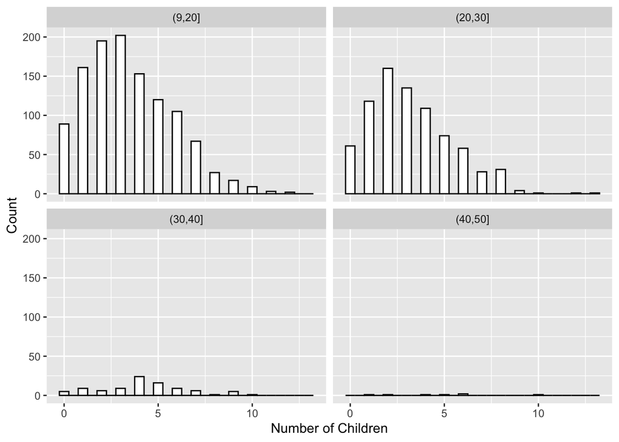

```r
cuts = cut(selectData$agefm,
           breaks=c(9, 20, 30, 40, 50))
agefmGrps <- data.frame(cuts, selectData)
ggplot(data = agefmGrps, aes(x = children)) +
  geom_histogram(binwidth = .5, color = "black",
                 fill = "white") +
  facet_wrap(cuts) +
  xlab("Number of Children") +
  ylab("Count")
```

```r
# Mean = Variance
table1chp4<- agefmGrps  %>% group_by(cuts)  %>%
  summarise(mnNum= mean(children),varNum=var(children),n=n())
kable(table1chp4, booktabs=T,
      caption="Compare mean and variance of number of children within each age group.",
      col.names = c("Educ Groups", "Mean", "Variance", "n")) %>%
  kable_styling(full_width = F)
```

Compare mean and variance of number of children within each age group.

[output not shown]

- ‘usemeth’

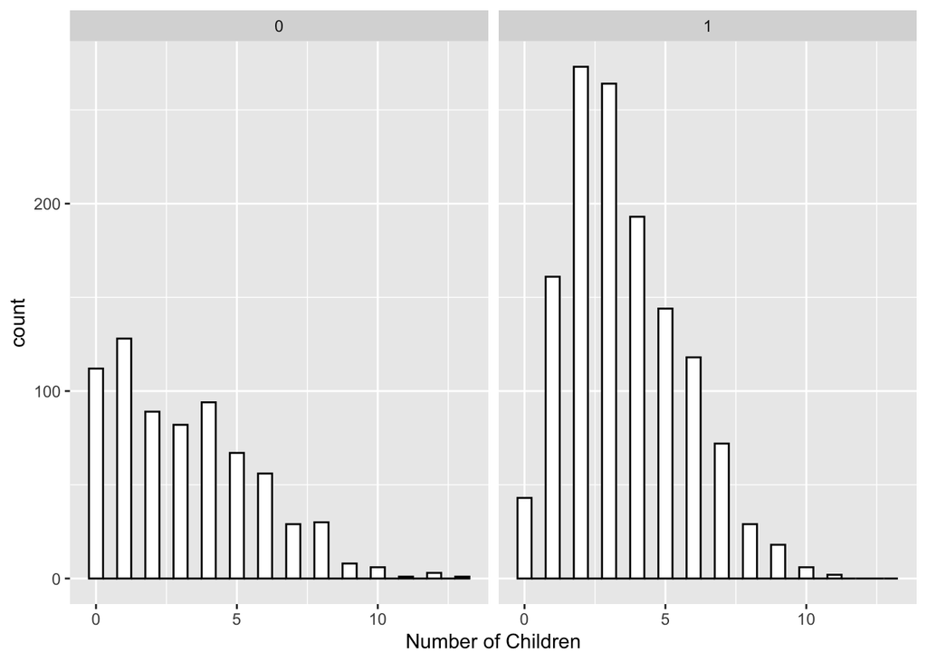

```r
ggplot(data = selectData, aes(x = children)) +
  geom_histogram(binwidth = .5, color = "black",
                 fill = "white") +
  facet_wrap(selectData$usemeth) +
  xlab("Number of Children")
```

```r
# Mean = Variance
table1chp4<- selectData  %>% group_by(usemeth)  %>%
  summarise(mnNum= mean(children),varNum=var(children),n=n())
kable(table1chp4, booktabs=T,
      caption="Compare mean and variance of number of children within each group.",
      col.names = c("Usemeth Groups", "Mean", "Variance", "n")) %>%
  kable_styling(full_width = F)
```

Compare mean and variance of number of children within each group.

| Usemeth Groups | Mean | Variance | n |
| --- | --- | --- | --- |
| 0 | 3.164306 | 6.608426 | 706 |
| 1 | 3.536659 | 4.312384 | 1323 |

- Summary: By looking at the data, some of the graph have too few data to show its distribution, so we don’t know if it will follow normal distribution as desired. From the table, we can see that some means and variance are not the same, which means the overdispersion might be a problem.

### Linearity

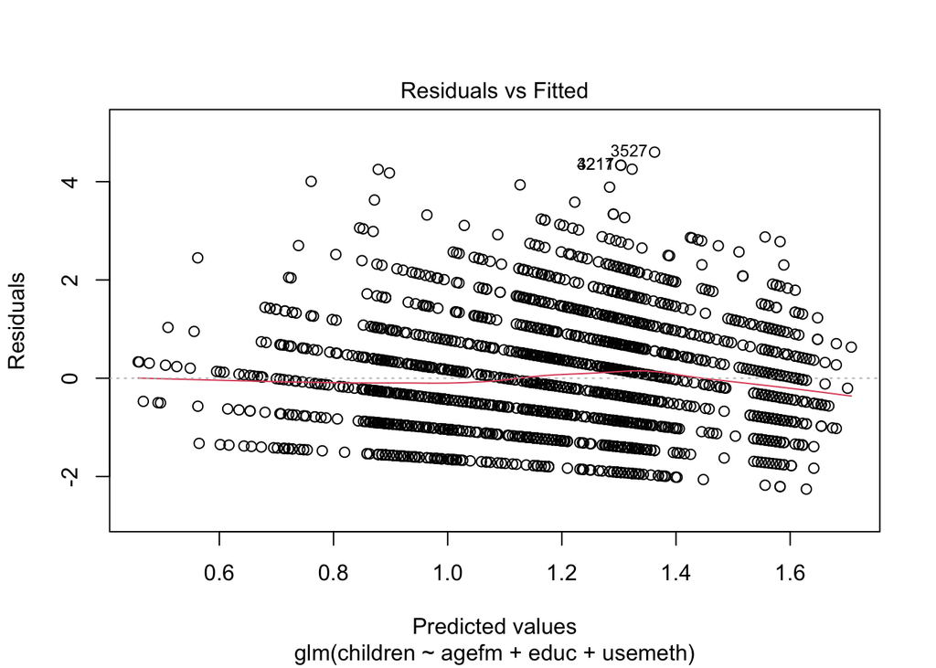

```r
model2 <- glm(children ~ agefm +educ+usemeth, family = 'poisson', data = selectData)
plot(model2, which = 1)
```

From residuals vs. fitted graph, we can see that the fitted line is about linear, which means the assumption of linearity is met.

### Model 2

### Poisson Response

Our response variable is the number of children each mother has. It’s a count value and it can be described by a Poisson Process. From the children data above, it follows right skewed normal distribution, so this also shows it’s a Poisson Response.

### Independence

In our project, each observation is a mother, so it is reasonable to assume that each observation is independent to each other.

### Mean = Variance

- ‘educ’

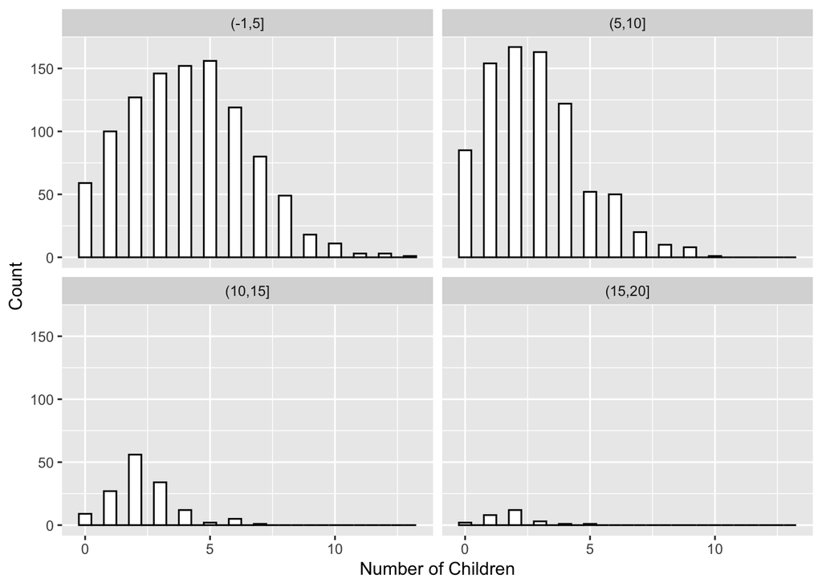

```r
cuts = cut(selectData$educ,
           breaks=c(-1,5,10,15,20))
educGrps <- data.frame(cuts, selectData)
ggplot(data = educGrps, aes(x = children)) +
  geom_histogram(binwidth = .5, color = "black",
                 fill = "white") +
  facet_wrap(cuts) +
  xlab("Number of Children") +
  ylab("Count")
```

```r
# Mean = Variance
table1chp4<- educGrps  %>% group_by(cuts)  %>%
  summarise(mnNum= mean(children),varNum=var(children),n=n())
kable(table1chp4, booktabs=T,
      caption="Compare mean and variance of number of children within each education group.",
      col.names = c("Age Groups", "Mean", "Variance", "n")) %>%
  kable_styling(full_width = F)
```

Compare mean and variance of number of children within each education group.

[output not shown]

- ‘age’

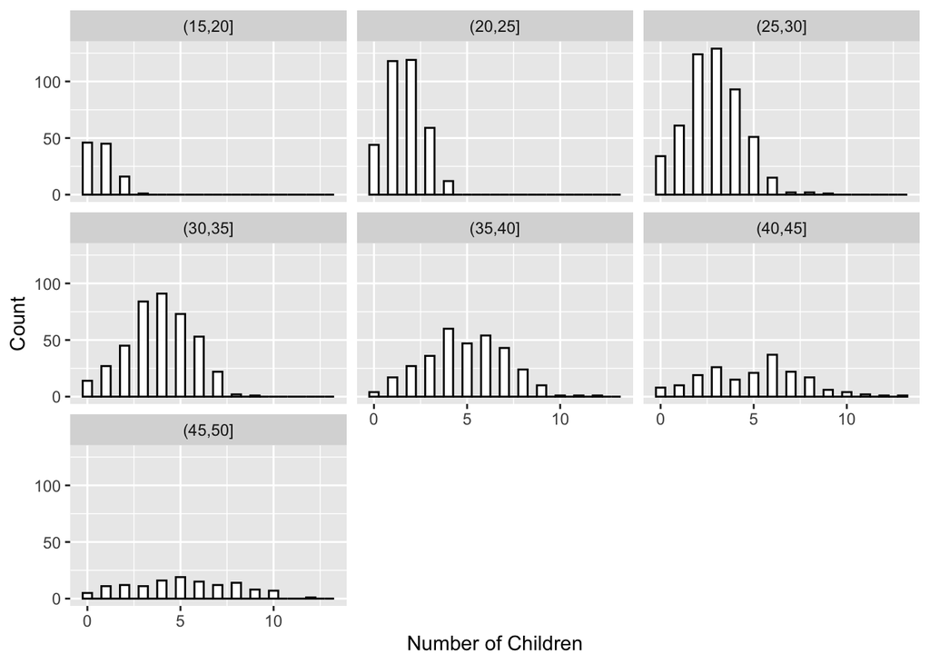

```r
cuts = cut(selectData$age,
           breaks=c(15,20,25,30,35,40,45,50))
ageGrps <- data.frame(cuts, selectData)
ggplot(data = ageGrps, aes(x = children)) +
  geom_histogram(binwidth = .5, color = "black",
                 fill = "white") +
  facet_wrap(cuts) +
  xlab("Number of Children") +
  ylab("Count")
```

```r
# Mean = Variance
table1chp4<- ageGrps  %>% group_by(cuts)  %>%
  summarise(mnNum= mean(children),varNum=var(children),n=n())
kable(table1chp4, booktabs=T,
      caption="Compare mean and variance of number of children within each age group.",
      col.names = c("Age Groups", "Mean", "Variance", "n")) %>%
  kable_styling(full_width = F)
```

Compare mean and variance of number of children within each age group.

| Age Groups | Mean | Variance | n |
| --- | --- | --- | --- |
| (15,20] | 0.7407407 | 0.5489789 | 108 |
| (20,25] | 1.6505682 | 1.0199997 | 352 |
| (25,30] | 2.8359375 | 2.3683341 | 512 |
| (30,35] | 3.8713592 | 3.0758687 | 412 |
| (35,40] | 4.9046154 | 4.7161823 | 325 |
| (40,45] | 4.9947090 | 6.9627378 | 189 |
| (45,50] | 5.0916031 | 7.7607751 | 131 |

- ‘urban’

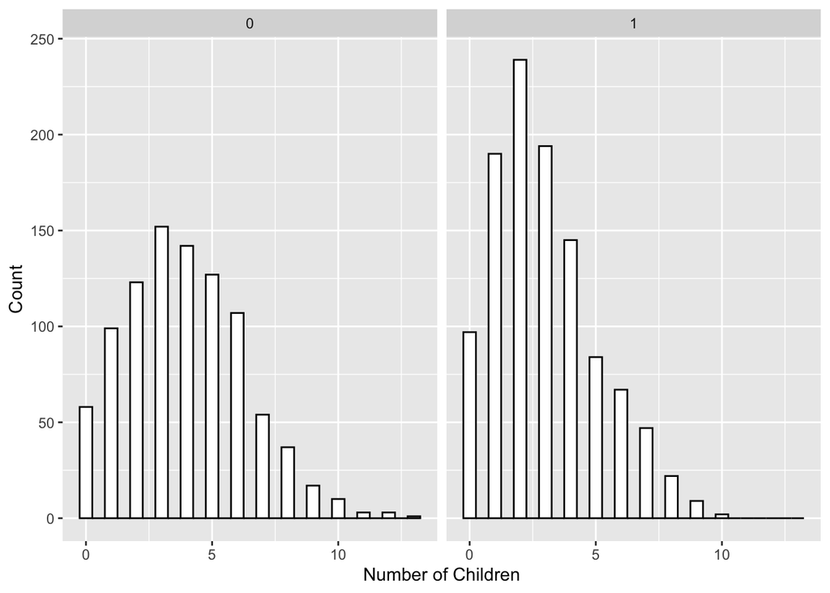

```r
ggplot(data = selectData, aes(x = children)) +
  geom_histogram(binwidth = .5, color = "black",
                 fill = "white") +
  facet_wrap(selectData$urban) +
  xlab("Number of Children") +
  ylab("Count")
```

```r
# Mean = Variance
table1chp4<- selectData  %>% group_by(urban)  %>%
  summarise(mnNum= mean(children),varNum=var(children),n=n())
kable(table1chp4, booktabs=T,
      caption="Compare mean and variance of number of children within each group.",
      col.names = c("Urban Groups", "Mean", "Variance", "n")) %>%
  kable_styling(full_width = F)
```

Compare mean and variance of number of children within each group.

| Urban Groups | Mean | Variance | n |
| --- | --- | --- | --- |
| 0 | 3.917470 | 5.680950 | 933 |
| 1 | 2.972628 | 4.273223 | 1096 |

- Summmary: From the graphs and tables, the mean and variance is not eactly the same for some group of data. Therefore, we need to check the overdispersion problem for this model too.

### Linearity

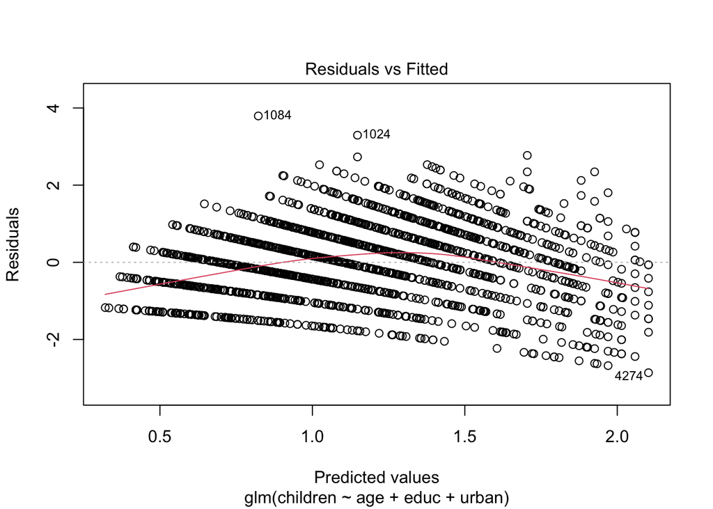

```r
model2 <- glm(children ~ age +educ+urban, family = 'quasipoisson', data = selectData)
plot(model2, which = 1)
```

## Model Fits

```r
model1 <- glm(children ~ agefm + educ +usemeth, family = poisson, data = selectData)
summary(model1)
```

```
##
## Call:
## glm(formula = children ~ agefm + educ + usemeth, family = poisson,
##     data = selectData)
##
## Deviance Residuals:
##     Min       1Q   Median       3Q      Max
## -3.1923  -0.9721  -0.1181   0.6555   3.6159
##
## Coefficients:
##              Estimate Std. Error z value Pr(>|z|)
## (Intercept)  1.185228   0.053476  22.164  < 2e-16 ***
## agefm        0.006567   0.002331   2.818  0.00484 **
## educ        -0.058856   0.003154 -18.662  < 2e-16 ***
## usemeth      0.265824   0.026867   9.894  < 2e-16 ***
## ---
## Signif. codes:  0 '***' 0.001 '**' 0.01 '*' 0.05 '.' 0.1 ' ' 1
##
## (Dispersion parameter for poisson family taken to be 1)
##
##     Null deviance: 3355.0  on 2028  degrees of freedom
## Residual deviance: 2971.2  on 2025  degrees of freedom
## AIC: 8649
##
## Number of Fisher Scoring iterations: 5
```

```r
model2 <- glm(children ~ age + educ + urban, family = poisson, data = selectData)
summary(model2)
```

```
##
## Call:
## glm(formula = children ~ age + educ + urban, family = poisson,
##     data = selectData)
##
## Deviance Residuals:
##     Min       1Q   Median       3Q      Max
## -4.0461  -0.7019  -0.0069   0.6186   2.9432
##
## Coefficients:
##              Estimate Std. Error z value Pr(>|z|)
## (Intercept) -0.062083   0.060219  -1.031    0.303
## age          0.044173   0.001545  28.589  < 2e-16 ***
## educ        -0.028115   0.003129  -8.986  < 2e-16 ***
## urban       -0.115205   0.025318  -4.550 5.36e-06 ***
## ---
## Signif. codes:  0 '***' 0.001 '**' 0.01 '*' 0.05 '.' 0.1 ' ' 1
##
## (Dispersion parameter for poisson family taken to be 1)
##
##     Null deviance: 3355.0  on 2028  degrees of freedom
## Residual deviance: 2220.4  on 2025  degrees of freedom
## AIC: 7898.2
##
## Number of Fisher Scoring iterations: 5
```

According to the summary of two models above, we can see that the AIC value for model 2 is relatively low, so here we choose the model 2 as a better predictor of the number of children than model 1. We cannot use the drop-in-deviance method here because these two models are not nested.

## Overdispersion

```r
X1 <- sum(residuals(model1, type = "pearson")^2)
phat1 <- X1/model1$df.residual
phat1
```

```
## [1] 1.334215
```

```r
X2 <- sum(residuals(model2, type = "pearson")^2)
phat2 <- X2/model2$df.residual
phat2
```

```
## [1] 0.8987825
```

Since mean and variance are not very equal as we shown before, the assumption may not very perfect in this. So we need to take the overdispersion into account. Since the value of two models’ dispersion parameters are not noticably greater than or less to 1, we don’t have to use the quasipoisson in this case.

## Goodness of fit test (model 2)

```r
#fit the pearson statistics parameters for model 1
X3 <- sum(residuals(model2, type = "pearson")^2)
#calculate the df
df <- model2$df.residual
#calculate the p-value
pvalue <- 1-pchisq(X3, df)
pvalue
```

```
## [1] 0.9995591
```

We have hypothesis: H0: the model 2 fits , H1: the model 2 does not fit. Since the p-value I get is 0.99, which is relatively high value, in that case we are to fail to reject the null hypothesis. In conclusion, according to the p-value we calculated, we say that the model 2 fits.

## Goodness of fit test (model 1)

```r
X4 <- sum(residuals(model1, type = "pearson")^2)
df2<- model1$df.residual
pvalue2 <- 1-pchisq(X4,df2)
pvalue2
```

```
## [1] 0
```

We have hypothesis: H0: the model 1 fits, H1: the model 1 does not fit. Since the p-value is 0, which is very small, in that case we have evidence to reject the null hypothesis. In conclusion, we say the model 1 does not fit.

## Conclusion

To recap:

### Question 1

Is the model using parameters ‘agefm’, ‘edu’, and ‘usemeth’ to predict the response variable ‘children’ efficient?

Model one displays this outlook. The model is not appropriate to predict the children response variable based on the goodness-of-fit (Chi-Squared) test, as we find a p-value equal to zero and reject the notion that the model fits.

### Question 3

Which model is better?

In terms of AIC values, we compare model 1 and model 2 for the lower value. In this comparison, we find that the AIC for model one (AIC = 8649) is much higher than that of model two (AIC = 7898.2). We deduct that model two is more effective in predicting the response variable ‘children’, similar to findings above.

# Multilevel Modeling Report

# About data

The dataset we are going to use was created by the people over at the UCLA Institute for Digital Research and Education (IDRE).

The dataset measures schools and teachers, as well as students. The researchers are interested in how the organizational structure of schools influences the performance of students, or how teacher characteristics such as experience, IQ, or teaching style have an impact on student learning.

Therefore, the level 1 observational unit is each student, and level 2 observational unit is school.

# Load data

```r
Multidata <- read_dta("https://stats.idre.ucla.edu/stat/examples/imm/imm23.dta")
```

# Research Question

Research Question 1: Does the time spent on homework each week affect a student’s math score?

Research Question 2: Does the association between time spent doing homework and math score depend on the type of school (private or public)?

# Parameter of Interest and Fixed Effect/Random Effect

Therefore, the parameters we will use are ‘homework’ (time spent on homework each week) and ‘public’ (1=public school, 0 = others). And our response variable is ‘math’ (math score for each student).

Fixed effects are the time spent on their homework and the type of school.

Random effect is the school, indicated by ‘schid’ (school ID).

## Parameter fine-tuning

We are not going to do any parameter tuning here, due to variables of interest having being already organized as indicators.

```r
head(Multidata)
```

```
## # A tibble: 6 × 18
##   schid stuid    ses meanses homework white parented public ratio percmin  math
##   <dbl> <dbl>  <dbl>   <dbl>    <dbl> <dbl>    <dbl>  <dbl> <dbl>   <dbl> <dbl>
## 1  6053     1  0.850   0.700        1     1        4      0    18       3    50
## 2  6053     2  0.430   0.700        1     1        3      0    18       3    43
## 3  6053     4 -0.590   0.700        3     0        3      0    18       3    50
## 4  6053    11  1.02    0.700        1     1        5      0    18       3    49
## 5  6053    12  0.840   0.700        1     1        5      0    18       3    62
## 6  6053    13  1.32    0.700        1     1        6      0    18       3    43
## # … with 7 more variables: sex <dbl>, race <dbl>, sctype <dbl>, cstr <dbl>,
## #   scsize <dbl>, urban <dbl>, region <dbl>
```

# Exploratory Data Analysis

## Univariate Plots

```r
Multidata %>%
  summarize(overallmean = mean(math, na.rm = TRUE),
            overallsd = sd(math, na.rm = TRUE))
```

```
## # A tibble: 1 × 2
##   overallmean overallsd
##         <dbl>     <dbl>
## 1        51.7      10.7
```

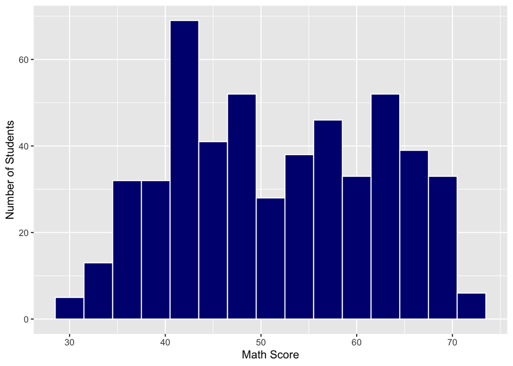

```r
math_all <- ggplot(data = Multidata, mapping = aes(x = math)) +
  geom_histogram(binwidth = 3, fill = "navy", color = "white") +
  labs(x = "Math Score",
       y = "Number of Students")

math_all
```

Based on the graph above, the distribution of math scores is approximately normal. The data is roughly symmetric about a score of 51. We can see that the majority of scores are between 41 and 64.

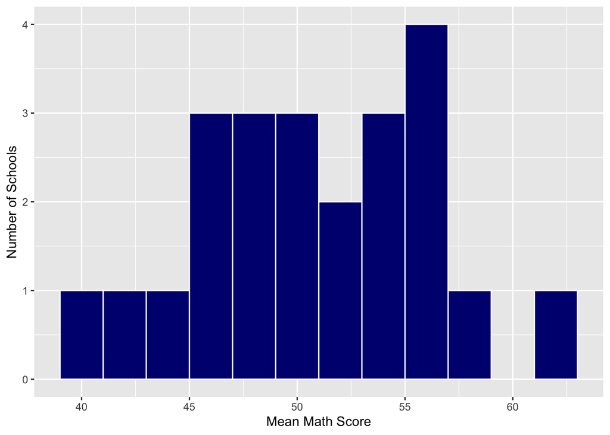

```r
math_agg <- Multidata %>%
  group_by(schid) %>%
  summarize(mean = mean(math, na.rm = TRUE),
            sd = sd(math, na.rm = TRUE)) %>%
  ggplot(mapping = aes(x = mean)) +
     geom_histogram(binwidth = 2, fill = "navy", color = "white") +
     labs(x = "Mean Math Score",
          y = "Number of Schools")

math_agg
```

Similar to the previous graph, the distribution of mean math scores per school is nearly normal; it is roughly symmetric around a score of 50. It seems that the majority of mean scores are between 45 and 57.

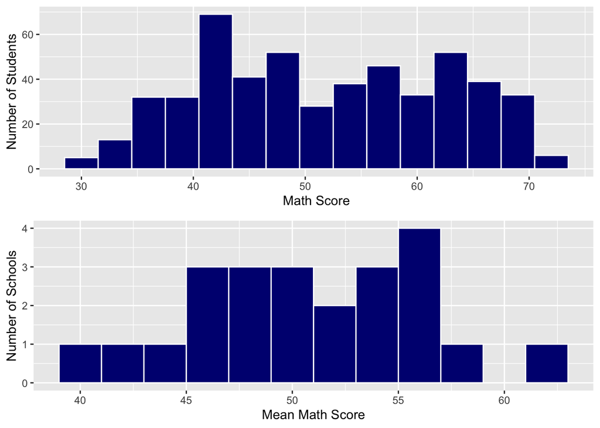

```r
# Plot with both univariate figures
grid.arrange(math_all,math_agg,ncol=1)
```

```r
# Changing indicator variable to text
Multidata <- Multidata%>%
    mutate(SchoolType = ifelse(public == 1, "Public", "Private"))

data_lev2 <-
  Multidata %>%
  group_by(schid) %>%
  filter(row_number() == 1)

# Creating proportions and table
table(data_lev2$SchoolType)
```

```
##
## Private  Public
##       8      15
```

```r
prop.table(table(data_lev2$SchoolType))
```

```
##
##   Private    Public
## 0.3478261 0.6521739
```

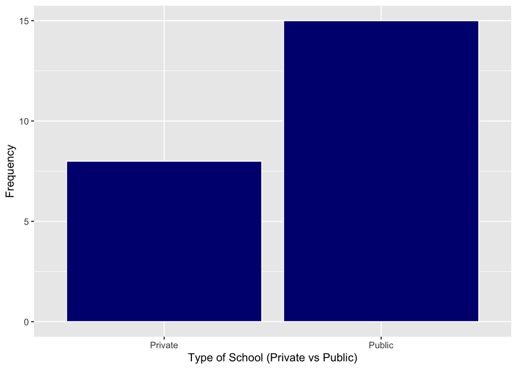

```r
# Plot
inst <- ggplot(data = data_lev2, mapping = aes(x = SchoolType)) +
  geom_bar(fill = "navy", color = "white") +
  labs(x = "Type of School (Private vs Public)",
       y = "Frequency")
inst
```

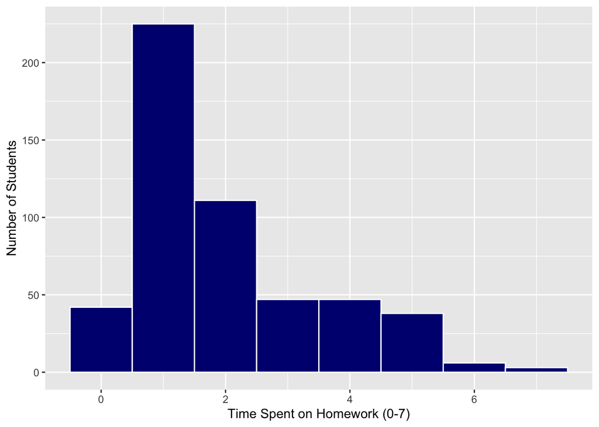

```r
hwAll <- ggplot(data = Multidata, mapping = aes(x = homework)) +
  geom_histogram(binwidth = 1, fill = "navy", color = "white") +
  labs(x = "Time Spent on Homework (0-7)",
       y = "Number of Students")

hwAll
```

# Bivariate Plots

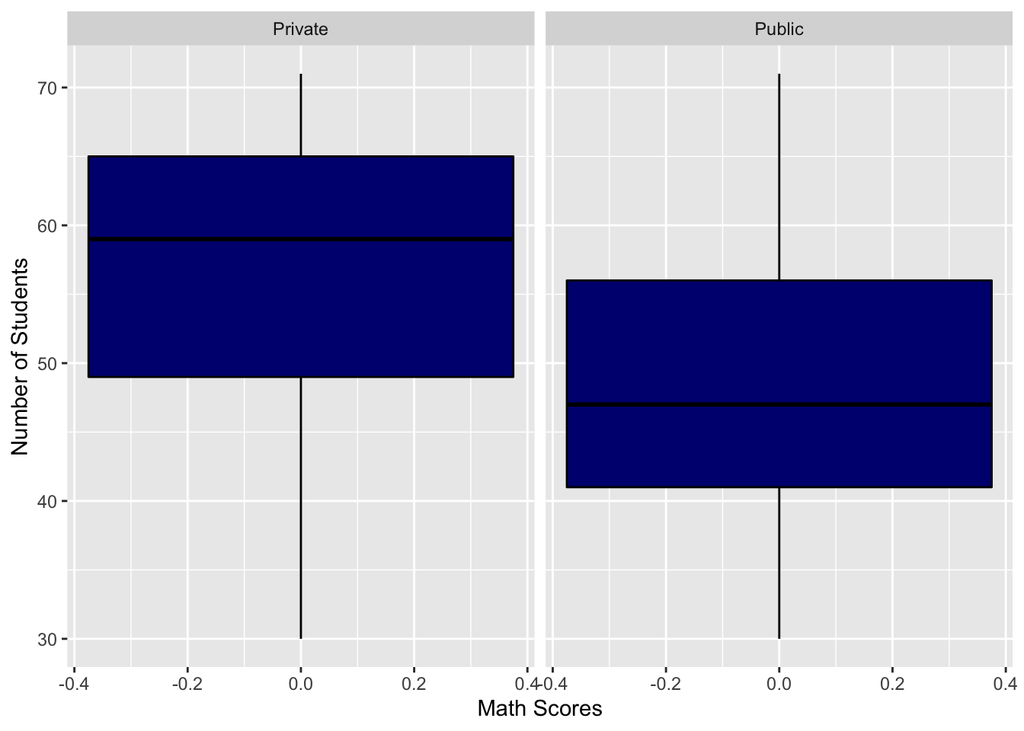

```r
bp <- ggplot(data = Multidata, mapping = aes(y = math)) +
  geom_boxplot(fill = "navy", color = "black") +
  labs(x = "Math Scores",
       y = "Number of Students") +
  facet_grid(. ~SchoolType)
bp
```

The spread of the private vs public math scores and the number of students is about the same for both types of schools, with the median for private schools (median = 59) being noticeable higher than that for public (median = 47) schools.

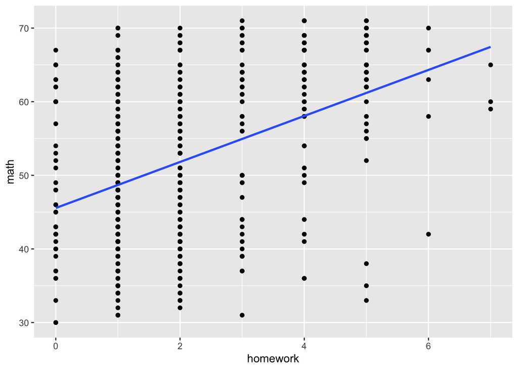

```r
plot <- ggplot(data = Multidata, mapping = aes(y = math, x = homework))+
  geom_point()+
  geom_smooth(method = "lm", se = F)

plot
```

We can assume linearity between amount of time spent on homework and math scores based on the graph above. There is a clear positive linear trend displayed by the blue line.

Lattice Plot:

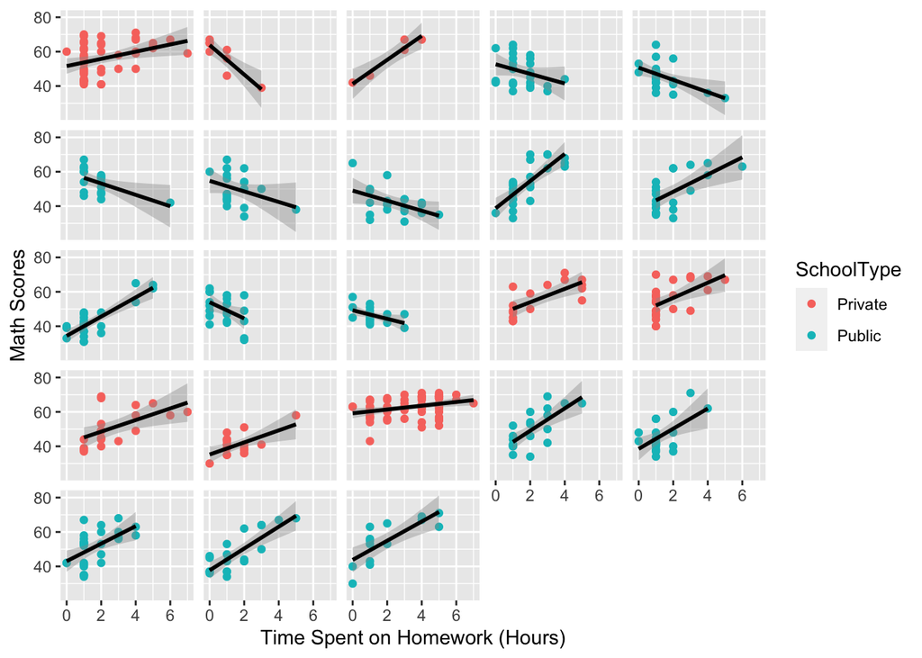

```r
ggplot(Multidata,aes(x=homework,y=math,color = SchoolType)) +
  geom_point() + geom_smooth(method="lm",color="black") +
  facet_wrap(~schid,ncol=5) +
  theme(strip.text.x=element_blank())  +
  labs(x="Time Spent on Homework (Hours)",y="Math Scores")
```

Similar evidence of linearity to the above plot shown in these individual plots per school. These plots also show that private schools have higher math scores on average than do public.

## Model Building

### Unconditional means model; which we will call Model_a (This is the model with no covariates and random intercepts only.) Model_a is given below:

$$\text{Level 1: } Y_{ij} = a_i +
\epsilon_{ij} \text{ where } \epsilon_{ij} \sim N(0,
\sigma^2)$$

$$\text{Level 2: } a_i = \alpha_0 + u_i
\text{ where } u_i \sim N(0, \sigma_u^2)$$

Composite model:

$$\text Y_{ij} = \alpha_0 + u_i +
\epsilon_{ij} \text{ where } \epsilon_{ij} \sim N(0, \sigma^2) \text{, }
u_i \sim N(0, \sigma_u^2)$$

```r
model_a <- lmer(math ~ 1 + (1|schid), REML = F, data = Multidata)
summary(model_a)
```

```
## Linear mixed model fit by maximum likelihood  ['lmerMod']
## Formula: math ~ 1 + (1 | schid)
##    Data: Multidata
##
##      AIC      BIC   logLik deviance df.resid
##   3806.8   3819.5  -1900.4   3800.8      516
##
## Scaled residuals:
##      Min       1Q   Median       3Q      Max
## -2.67819 -0.72760 -0.01965  0.73306  2.67062
##
## Random effects:
##  Groups   Name        Variance Std.Dev.
##  schid    (Intercept) 24.85    4.985
##  Residual             81.24    9.013
## Number of obs: 519, groups:  schid, 23
##
## Fixed effects:
##             Estimate Std. Error t value
## (Intercept)   50.757      1.127   45.05
```

```r
coef(model_a)
```

```
## $schid
##       (Intercept)
## 6053     55.93361
## 6327     55.45531
## 6467     54.29023
## 7194     48.73395
## 7472     46.36363
## 7474     53.42770
## 7801     50.17713
## 7829     43.35924
## 7930     52.95119
## 24371    48.68821
## 24725    44.47846
## 25456    49.97926
## 25642    47.01216
## 26537    55.42197
## 46417    55.08112
## 47583    51.00890
## 54344    42.38745
## 62821    62.25969
## 68448    49.81359
## 68493    46.92925
## 72080    51.27114
## 72292    48.25846
## 72991    54.13897
##
## attr(,"class")
## [1] "coef.mer"
```

#### Intraclass Correlation Coefficient

```r
rho <- (24.85)/(24.85+81.24)
rho
```

```
## [1] 0.2342351
```

About 23.4% of the total variability in math scores is due to differences between schools. This value being above 10% (or rho = 0.10) gives us evidence to use a multilevel modeling technique. Therefore it is good that we decided to use the multileveling model for our research question(s).

### Model 1: Add homework as a level 1 covariate

$$\text{Level 1: } Y_{ij} = a_i +
b_{i}x_{i,homework} + \epsilon_{ij} \text{ where } \epsilon_{ij} \sim
N(0, \sigma^2)$$

$$\text{Level 2: } a_i = \alpha_0 + u_i$$
$$b_i = \beta_0 + v_i \text{ where
} \begin{bmatrix} u_i \\ v_i \end{bmatrix} \sim N(\begin{bmatrix} 0 \\ 0
\end{bmatrix}, \begin{bmatrix} \sigma_u^2 \\ \rho\sigma_u\sigma_v &
\sigma_v^2 \end{bmatrix})$$

Composite model:

$$\text Y_{ij} = \alpha_0 +
\beta_0x_{i,homework} + u_i + v_ix_{i,homework}+ \epsilon_{ij} \text{
where } \epsilon_{ij} \sim N(0, \sigma^2) \text{, } \begin{bmatrix} v_i
\\ u_i \end{bmatrix} \sim N(\begin{bmatrix} 0 \\ 0 \end{bmatrix},
\begin{bmatrix} \sigma_u^2 \\ \rho\sigma_u\sigma_v & \sigma_v^2
\end{bmatrix})$$

```r
model1 <- lmer(math ~ homework + (1+homework|schid), REML = F, data = Multidata)
summary(model1)
```

```
## Linear mixed model fit by maximum likelihood  ['lmerMod']
## Formula: math ~ homework + (1 + homework | schid)
##    Data: Multidata
##
##      AIC      BIC   logLik deviance df.resid
##   3651.0   3676.5  -1819.5   3639.0      513
##
## Scaled residuals:
##      Min       1Q   Median       3Q      Max
## -2.22035 -0.70448  0.00578  0.66238  2.74920
##
## Random effects:
##  Groups   Name        Variance Std.Dev. Corr
##  schid    (Intercept) 59.28    7.700
##           homework    16.79    4.097    -0.83
##  Residual             53.30    7.301
## Number of obs: 519, groups:  schid, 23
##
## Fixed effects:
##             Estimate Std. Error t value
## (Intercept)   46.322      1.720  26.940
## homework       1.987      0.906   2.193
##
## Correlation of Fixed Effects:
##          (Intr)
## homework -0.823
```

```r
coef(model1)
```

```
## $schid
##       (Intercept)  homework
## 6053     51.10365  2.170454
## 6327     60.98937 -5.933916
## 6467     41.94978  6.119491
## 7194     51.85334 -2.185891
## 7472     50.26733 -2.922046
## 7474     57.74118 -2.567550
## 7801     53.66276 -2.422275
## 7829     49.28999 -2.766864
## 7930     39.54583  7.369863
## 24371    39.40948  4.666987
## 24725    35.53437  5.339936
## 25456    52.80554 -3.171453
## 25642    48.40124 -1.350273
## 26537    45.71089  3.900367
## 46417    47.28690  4.292934
## 47583    42.54675  3.191349
## 54344    36.81324  3.235196
## 62821    57.83568  1.374034
## 68448    37.72503  5.866246
## 68493    39.50227  5.294461
## 72080    43.34677  4.808121
## 72292    38.47627  6.001557
## 72991    43.62055  5.387532
##
## attr(,"class")
## [1] "coef.mer"
```

$$\hat{\alpha_0} = 46.32 = \text{the mean
math score when the time spent on homework is zero hours }$$

$$\hat{\beta_0} = 1.99 = \text{the mean
change in math score when the time spent on homework increases by one
hour }$$
$$\hat{\sigma}^2 = 53.30 =
\text{the variance in math score in within school deviations }$$
$$\hat{\sigma_u}^2 = 59.28 = \text{the
variance in math score in between-school deviations when the time spent
on homework is zero hour }$$
$$\hat{\sigma_v}^2 = 16.79 = \text{the variance in math score in
between-school deviations as the time spent on homework increases by one
hour }$$

The model output and analysis following here show that homework is a good level 1 covariate. We note that for homework, |t| value is above the threshold of 2:

t = 2.193

R output does not provide p-values because there are varying degrees of freedom, so for |t| > 2, we say that homework is a significant predictor of math score in this multilevel model.

### Model 2: Adding a level 2 covariate of ‘public’ to model 1

$$\text{Level 1: } Y_{ij} = a_i +
b_{i}x_{i,homework} + \epsilon_{ij} \text{ where } \epsilon_{ij} \sim
N(0, \sigma^2)$$

$$\text{Level 2: } a_i = \alpha_0 +
\alpha_{1}x_{i,public} + u_i$$
$$b_i
= \beta_0 + \beta_{1}x_{i,public} + v_i \text{ where } \begin{bmatrix}
u_i \\ v_i \end{bmatrix} \sim N(\begin{bmatrix} 0 \\ 0 \end{bmatrix},
\begin{bmatrix} \sigma_u^2 \\ \rho\sigma_u\sigma_v & \sigma_v^2
\end{bmatrix})$$

Composite model:

$$\text Y_{ij} = [\alpha_0 +
\alpha_{1}x_{i,public} + \beta_0x_{i,homework} +
\beta_{1}x_{i,public}x_{i,homework}] + [u_i + v_ix_{i,homework}+
\epsilon_{ij} \text{ where } \epsilon_{ij}] \sim N(0, \sigma^2) \text{,
} \begin{bmatrix} v_i \\ u_i \end{bmatrix} \sim N(\begin{bmatrix} 0 \\ 0
\end{bmatrix}, \begin{bmatrix} \sigma_u^2 \\ \rho\sigma_u\sigma_v &
\sigma_v^2 \end{bmatrix})$$

```r
model2 <- lmer(math ~ homework + public + public:homework + (1+homework + public|schid), REML = F, data = Multidata)
summary(model2)
```

```
## Linear mixed model fit by maximum likelihood  ['lmerMod']
## Formula: math ~ homework + public + public:homework + (1 + homework +
##     public | schid)
##    Data: Multidata
##
##      AIC      BIC   logLik deviance df.resid
##   3651.9   3698.6  -1814.9   3629.9      508
##
## Scaled residuals:
##      Min       1Q   Median       3Q      Max
## -2.29956 -0.70182 -0.02623  0.65169  2.73176
##
## Random effects:
##  Groups   Name        Variance Std.Dev. Corr
##  schid    (Intercept) 92.00    9.591
##           homework    15.91    3.989    -0.83
##           public      61.83    7.863    -0.74  0.25
##  Residual             53.47    7.313
## Number of obs: 519, groups:  schid, 23
##
## Fixed effects:
##                 Estimate Std. Error t value
## (Intercept)      48.3832     3.5812  13.510
## homework          2.4075     1.4962   1.609
## public           -3.1449     4.0186  -0.783
## homework:public  -0.5902     1.8545  -0.318
##
## Correlation of Fixed Effects:
##             (Intr) homwrk public
## homework    -0.823
## public      -0.891  0.733
## homwrk:pblc  0.664 -0.807 -0.834
## optimizer (nloptwrap) convergence code: 0 (OK)
## unable to evaluate scaled gradient
## Model failed to converge: degenerate  Hessian with 1 negative eigenvalues
```

```r
coef(model2)
```

```
## $schid
##       (Intercept)   homework      public homework:public
## 6053     51.46587  2.1096319  -6.7748012      -0.5902199
## 6327     61.36252 -4.8490132  -4.6702582      -0.5902199
## 6467     42.93597  5.9391047  -3.6190312      -0.5902199
## 7194     55.69059 -1.5934536  -4.0888407      -0.5902199
## 7472     61.13616 -2.3257795 -10.6668473      -0.5902199
## 7474     48.65116 -1.6875736   7.1328054      -0.5902199
## 7801     54.03580 -1.8167351  -0.9255315      -0.5902199
## 7829     62.03080 -2.3492250 -12.0005171      -0.5902199
## 7930     33.44123  8.0509487   5.4129736      -0.5902199
## 24371    45.28021  5.1735299  -5.5310338      -0.5902199
## 24725    48.19474  5.8444141 -11.8275447      -0.5902199
## 25456    58.82382 -2.7083658  -6.0622280      -0.5902199
## 25642    57.17923 -0.7286679  -8.6685614      -0.5902199
## 26537    46.33954  3.7911180  -3.4572085      -0.5902199
## 46417    47.78736  4.1982822  -6.4159742      -0.5902199
## 47583    42.57978  3.2219809   3.1072160      -0.5902199
## 54344    35.99134  3.6364916  11.3743463      -0.5902199
## 62821    58.60333  1.2124026 -14.7035523      -0.5902199
## 68448    42.76240  6.3343026  -4.6369755      -0.5902199
## 68493    42.58513  5.8094807  -2.9898539      -0.5902199
## 72080    38.63234  5.4264956   4.1735722      -0.5902199
## 72292    41.02475  6.5545393  -2.5028605      -0.5902199
## 72991    36.27986  6.1285874   6.0078246      -0.5902199
##
## attr(,"class")
## [1] "coef.mer"
```

### Model 2: Reducing Complexity

We also removed the interaction term between public and homework for model for simplicity. This may improve significance results.

These two actions solve the issue we were having with model two above.

$$\text{Level 1: } Y_{ij} = a_i +
b_{i}x_{i,homework} + \epsilon_{ij} \text{ where } \epsilon_{ij} \sim
N(0, \sigma^2)$$

$$\text{Level 2: } a_i = \alpha_0 +
\alpha_{1}x_{i,public} + u_i$$
$$b_i
= \beta_0 + \beta_{1}x_{i,public} \text{ where } u_i \sim N(0,
\sigma_u^2)$$

Composite model:

```r
model2.reduced <- lmer(math ~ homework + public + (1 + homework|schid), REML = F, data = Multidata)
summary(model2.reduced)
```

```
## Linear mixed model fit by maximum likelihood  ['lmerMod']
## Formula: math ~ homework + public + (1 + homework | schid)
##    Data: Multidata
##
##      AIC      BIC   logLik deviance df.resid
##   3648.8   3678.6  -1817.4   3634.8      512
##
## Scaled residuals:
##      Min       1Q   Median       3Q      Max
## -2.23159 -0.71818  0.00015  0.68636  2.67120
##
## Random effects:
##  Groups   Name        Variance Std.Dev. Corr
##  schid    (Intercept) 56.25    7.500
##           homework    16.37    4.046    -0.86
##  Residual             53.34    7.304
## Number of obs: 519, groups:  schid, 23
##
## Fixed effects:
##             Estimate Std. Error t value
## (Intercept)  49.0650     2.1128  23.223
## homework      1.9821     0.8957   2.213
## public       -4.0820     1.8952  -2.154
##
## Correlation of Fixed Effects:
##          (Intr) homwrk
## homework -0.680
## public   -0.606  0.010
```

```r
coef(model2.reduced)
```

```
## $schid
##       (Intercept)  homework    public
## 6053     51.31027  2.136151 -4.082024
## 6327     61.31041 -5.481797 -4.082024
## 6467     43.30997  5.893534 -4.082024
## 7194     55.79370 -2.180722 -4.082024
## 7472     54.26520 -2.908670 -4.082024
## 7474     61.39931 -2.527508 -4.082024
## 7801     57.56529 -2.424001 -4.082024
## 7829     53.22642 -2.725305 -4.082024
## 7930     43.34962  7.393873 -4.082024
## 24371    43.30124  4.695080 -4.082024
## 24725    39.55670  5.344687 -4.082024
## 25456    56.84260 -3.253948 -4.082024
## 25642    52.40994 -1.370213 -4.082024
## 26537    46.44630  3.764454 -4.082024
## 46417    47.61972  4.240947 -4.082024
## 47583    43.44783  3.021347 -4.082024
## 54344    37.47097  3.234408 -4.082024
## 62821    57.94860  1.350112 -4.082024
## 68448    41.57289  5.912515 -4.082024
## 68493    43.49056  5.243928 -4.082024
## 72080    47.23708  4.803793 -4.082024
## 72292    42.38940  5.997561 -4.082024
## 72991    47.22987  5.427852 -4.082024
##
## attr(,"class")
## [1] "coef.mer"
```

$$\hat{\alpha_0} = 49.07 = \text{the mean
math score when the time spent on homework is zero hours {homework = 0}
for private schools {public = 0} }$$
$$\hat{\alpha_1} = -4.08 = \text{the mean math
score for public {public = 1} schools compared to private {public = 0}
schools, controlling for the effects of time spent on homework }$$
$$\hat{\beta_1} = 1.98 = \text{the
mean change in math score when time spent on homework increases by one
hour, controlling for the effects of school type }$$
The first note of this model is that there are no issues in complexity for computing the model in R. We also note that both for homework and public, |t| values are above the threshold of 2:

homework: t = 2.213 public: t = -2.154

Again, with the absence of p-values, we generally accept |t| > 2 as significant in multilevel modeling. This gives evidence that our model2.reduced is likely a good model build to predict math score based on the time spent on homework and school type.

To properly test the nested models, the models should have corresponding levels of complexity. This should not be an issue because we eliminated error from the ‘public’ variable.

## Model Comparisons

### Drop-in-Deviance Tests

Hypotheses:

Null: Model 1, including homework as the only covariate, is preferred to Model 2

$$\alpha_{1}x_{i,public} = 0$$

Alternative: Model 2, including homework and public (binary for private or public school) is preferred to Model 1.

$$\alpha_{1}x_{i,public} \neq
0$$

```r
# Both models need same variance structure to use a drop-in-deviance test
# We add the variance term associated with public in order to account for this
model2.reducedI <- lmer(math ~ homework + public + (1 + homework + public|schid), REML = F, data = Multidata)
# Drop-in-deviance
anova(model1, model2.reducedI, test = "Chisq")
```

```
## Data: Multidata
## Models:
## model1: math ~ homework + (1 + homework | schid)
## model2.reducedI: math ~ homework + public + (1 + homework + public | schid)
##                 npar  AIC    BIC  logLik deviance  Chisq Df Pr(>Chisq)
## model1             6 3651 3676.5 -1819.5     3639
## model2.reducedI   10 3650 3692.5 -1815.0     3630 9.0584  4    0.05966 .
## ---
## Signif. codes:  0 '***' 0.001 '**' 0.01 '*' 0.05 '.' 0.1 ' ' 1
```

```r
# The code may generate a warning due to the complexity of the models being compared
```

Test Statistic: 9.0584 P-value: 0.0597 Decision: Fail to reject null hypothesis Conclusion: The model with homework and public is shown to not be significantly better than the model with only homework. Due to this, the model with just homework is preferred.

```r
# Testing without accounting for complexity (similar to online book notes 8.6.2)
model1.reduced <- lmer(math ~ homework + (1|schid), REML = F, data = Multidata)
coef(model1)
```

```
## $schid
##       (Intercept)  homework
## 6053     51.10365  2.170454
## 6327     60.98937 -5.933916
## 6467     41.94978  6.119491
## 7194     51.85334 -2.185891
## 7472     50.26733 -2.922046
## 7474     57.74118 -2.567550
## 7801     53.66276 -2.422275
## 7829     49.28999 -2.766864
## 7930     39.54583  7.369863
## 24371    39.40948  4.666987
## 24725    35.53437  5.339936
## 25456    52.80554 -3.171453
## 25642    48.40124 -1.350273
## 26537    45.71089  3.900367
## 46417    47.28690  4.292934
## 47583    42.54675  3.191349
## 54344    36.81324  3.235196
## 62821    57.83568  1.374034
## 68448    37.72503  5.866246
## 68493    39.50227  5.294461
## 72080    43.34677  4.808121
## 72292    38.47627  6.001557
## 72991    43.62055  5.387532
##
## attr(,"class")
## [1] "coef.mer"
```

```r
coef(model2.reduced)
```

```
## $schid
##       (Intercept)  homework    public
## 6053     51.31027  2.136151 -4.082024
## 6327     61.31041 -5.481797 -4.082024
## 6467     43.30997  5.893534 -4.082024
## 7194     55.79370 -2.180722 -4.082024
## 7472     54.26520 -2.908670 -4.082024
## 7474     61.39931 -2.527508 -4.082024
## 7801     57.56529 -2.424001 -4.082024
## 7829     53.22642 -2.725305 -4.082024
## 7930     43.34962  7.393873 -4.082024
## 24371    43.30124  4.695080 -4.082024
## 24725    39.55670  5.344687 -4.082024
## 25456    56.84260 -3.253948 -4.082024
## 25642    52.40994 -1.370213 -4.082024
## 26537    46.44630  3.764454 -4.082024
## 46417    47.61972  4.240947 -4.082024
## 47583    43.44783  3.021347 -4.082024
## 54344    37.47097  3.234408 -4.082024
## 62821    57.94860  1.350112 -4.082024
## 68448    41.57289  5.912515 -4.082024
## 68493    43.49056  5.243928 -4.082024
## 72080    47.23708  4.803793 -4.082024
## 72292    42.38940  5.997561 -4.082024
## 72991    47.22987  5.427852 -4.082024
##
## attr(,"class")
## [1] "coef.mer"
```

```r
# Drop-in-deviance
anova(model1, model2.reduced, test = "Chisq")
```

```
## Data: Multidata
## Models:
## model1: math ~ homework + (1 + homework | schid)
## model2.reduced: math ~ homework + public + (1 + homework | schid)
##                npar    AIC    BIC  logLik deviance  Chisq Df Pr(>Chisq)
## model1            6 3651.0 3676.5 -1819.5   3639.0
## model2.reduced    7 3648.8 3678.6 -1817.4   3634.8 4.1955  1    0.04053 *
## ---
## Signif. codes:  0 '***' 0.001 '**' 0.01 '*' 0.05 '.' 0.1 ' ' 1
```

Test Statistic: 4.1955 P-value: 0.04053 Decision: Reject null hypothesis Conclusion: The model with homework and public is shown in this test to be significantly better than the model with only homework. Due to this, the model with homework and public is preferred.

### AIC Comparison

```r
summary(model1)
```

```
## Linear mixed model fit by maximum likelihood  ['lmerMod']
## Formula: math ~ homework + (1 + homework | schid)
##    Data: Multidata
##
##      AIC      BIC   logLik deviance df.resid
##   3651.0   3676.5  -1819.5   3639.0      513
##
## Scaled residuals:
##      Min       1Q   Median       3Q      Max
## -2.22035 -0.70448  0.00578  0.66238  2.74920
##
## Random effects:
##  Groups   Name        Variance Std.Dev. Corr
##  schid    (Intercept) 59.28    7.700
##           homework    16.79    4.097    -0.83
##  Residual             53.30    7.301
## Number of obs: 519, groups:  schid, 23
##
## Fixed effects:
##             Estimate Std. Error t value
## (Intercept)   46.322      1.720  26.940
## homework       1.987      0.906   2.193
##
## Correlation of Fixed Effects:
##          (Intr)
## homework -0.823
```

```r
summary(model2.reduced)
```

```
## Linear mixed model fit by maximum likelihood  ['lmerMod']
## Formula: math ~ homework + public + (1 + homework | schid)
##    Data: Multidata
##
##      AIC      BIC   logLik deviance df.resid
##   3648.8   3678.6  -1817.4   3634.8      512
##
## Scaled residuals:
##      Min       1Q   Median       3Q      Max
## -2.23159 -0.71818  0.00015  0.68636  2.67120
##
## Random effects:
##  Groups   Name        Variance Std.Dev. Corr
##  schid    (Intercept) 56.25    7.500
##           homework    16.37    4.046    -0.86
##  Residual             53.34    7.304
## Number of obs: 519, groups:  schid, 23
##
## Fixed effects:
##             Estimate Std. Error t value
## (Intercept)  49.0650     2.1128  23.223
## homework      1.9821     0.8957   2.213
## public       -4.0820     1.8952  -2.154
##
## Correlation of Fixed Effects:
##          (Intr) homwrk
## homework -0.680
## public   -0.606  0.010
```

AIC and BIC are model comparison values used when models are not able to be compared in other ways. The summaries’ above show that the model 1 AIC (AIC = 3651.0) is slightly higher than that of model 2 (AIC = 3648.8). But, the BIC for model 1 (BIC = 3676.5) is slightly lower than that of model 2 (BIC = 3678.6 ). This is likely because BIC punishes for addition of parameters more so than does AIC.

Because AIC/BIC give conflicting answers to preferred model, it is best to assume the model with less parameters is better. We therefore deduct that model 1 is preferred to model 2 in AIC/BIC comparison.

# Model Analysis

## Goodness of fit

```r
# We will perform a goodness of fit test for Model2.reducedI
ts <- sum(residuals(model2.reducedI, type = "pearson")^2)
pval <- 1-pchisq(ts, 518)

ts
```

```
## [1] 25734.71
```

```r
pval
```

```
## [1] 0
```

Hypothesis:

Null: The model fits Alternative: The model does not fit

Test Stat: 25734.71 P-value: 0 Conclusion: Based on the large test statistic and small p-value we can conclude that the model with homework and public and both variance terms does not fit.

```r
# Goodness of fit test for model 1
ts <- sum(residuals(model1, type = "pearson")^2)
pval <- 1-pchisq(ts, 518)

ts
```

```
## [1] 25533.57
```

```r
pval
```

```
## [1] 0
```

Hypothesis:

Null: The model fits Alternative: The model does not fit

Test Stat: 25533.57 P-value: 0 Conclusion: Based on the large test statistic and small p-value we can conclude that the model with homework and a homework variance term does not fit.

## Conclusion in Context

The research questions stated at the beginning are repeated below for convenience:

Research Question 1: Does the time spent on homework each week affect a student’s math score?

The answer to research question 1 can be evaluated using AIC as a comparison metric. The AIC for model 1, the model which has only homework as the predictor for math, is 3651.0. The AIC for model2 is 3651.9 and that for model2.reduced is 3648.8. Based on this, it can be seen that the model with homework as a predictor is as good as models with public and an interaction term, based on AIC.

Research Question 2: Does the association between time spent doing homework and math score depend on the type of school (private or public)?